# Science in society Incentives and obligations

Rob Davies

## We are learning how to think critically for ourselves

*Active learning* works best even if it sometimes feel challenging

- Active learning is what you do when you ask or answer questions
- We will prompt you sometimes with Activate

**Activate**

How will your work as a Psychologist have impact?

## What we are going to do

We are going to reflect critically on how we practise science communication

1. The representation of credibility, uncertainty, and generalizability
2. The role of story telling
3. The use of clear or persuasive language or visualizations
4. The ethics of practice in science communication

## Activate

Our primary learning question is this:

**Activate**

- Where is the point of balance at which I can match my sense of ethics to my practices?

## Science and society

We are going to work in the zone at the intersection between science and society

- All (most) scientists want to have *impact*
  - To influence policy makers and practitioners
  - To get funding, prestige, power
  - To sell books, ideas, talks, consulting services, tests, clicks

## Science and society

- All (most) scientists will be affected by
  - The priorities of funders or policymakers
  - The concerns and interests of practitioners, patients and the public
  - What work accrues reputational credit
  - What work is accepted, published
  - What work sells

## Science operating within society

**Tip**

Thus we have to see ourselves as operating

- not just within a field or network of other scientists (Bourdieu, 2004)
- but within wider social fields or networks

## We need to talk about communication

- Whereas we have reflected on science, theory, and hypothesis testing
- We now need to reflect critically on practices of *communication* in science
  - What and how we communicate to others about our motivations, what we do, what we find, what the implications of our findings are

## We will engage with tensions we may not be able to resolve

We will look at credibility

- What kinds of methods, observations, or conclusions are represented as credible

## We will engage with tensions we may not be able to resolve

We will look at our obligations to represent uncertainty in our theory, our methods, our observations, our conclusions

- The challenges we may face in seeking to represent uncertainty
- More or less effective ways of representing uncertainty
- The impacts of choices on claims on authority or credibility

## We will engage with tensions we may not be able to resolve

We will look at our obligations to represent generalizability in our theory, our methods, our observations, our conclusions

- Challenges we may face in seeking to represent generalizability

## We will engage with tensions we may not be able to resolve

We will, in looking at scientific communication, discuss the tension between

- Increasing expertise or specialization and its impact on the readability of what we say
- Recommendations to use plain language, to make things readable, to tell a story, to have impact

## We will engage with tensions we may not be able to resolve

We will look at the ways in which using persuasive language or story-telling can be

- Recommended as a means to effect influence or impact
- Unethical or quesionable as a scientific practice
- Helpful or enlightening or stimulating as a means to think critically

## Activate

Our learning questions then are these:

**Activate**

1. What are our incentives or interests?
2. What are our obligations and responsibilities?
3. How should we communicate our science?
4. How does thinking about ethics shape our communication practices?

## Reflections on recommendations for how we do and how we represent science

**What we can do**

- We will reflect *critically* on what appear to be helpful recommendations for how we do and how we represent (our) science
  - Considering ways to respond to these recommendations
  - Considering limitations, origins, and alternatives

## The normal business of science: solving puzzles

- Most of the time, scientists, working as members of a community or a tradition, work within a *shared understanding* of:
  - what problems are worth investigating
  - what solutions are possible
  - what methods can be used
- In the context of this **paradigm** (Kuhn, 1970), the scientist can spend their time figuring out solutions to the uncertainties that remain: *solving puzzles*

## Anomalies and revolutionary change

But over time scientists may come to see a (Kuhn, 1970):

> … persistent failure of the puzzles of normal science to come out as they should

A time of *crisis* ensues, leading to rejection of one paradigm, and acceptance of another

**Reading**

In Psychology, we have been through our own crises and now work in a revolutionary moment (Vazire, 2018): the *credibility revolution*

## The credibility revolution

Vazire (2018) identifies a credibility revolution:

- Greater emphasis on transparency and openness
- Move toward preregistration of research
- More direct-replication studies
- Higher standards for the kinds of evidence needed to make claims

## The science reform movement recommendations

A core set of recommendations can be found in manifestos like Munafò et al. (2017):

- Promote pre-registration
- Improve quality of reporting (checklists)
- Protect against conflicts of interest
- Encourage transparency and open science
- Diversify peer review
- Reward open and reproducible practices

## Changes in practice

We *do* see changes in practice (Nosek et al., 2022):

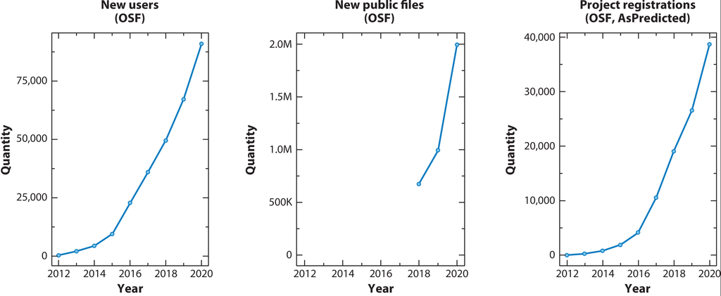

Nosek et al. (2022): Growth in counts of users, sharing of files (research data, materials, code), and registration of studies

## Critical self-awareness: peer review as a previous change to maintain credibility

- We see peer review emerging over time, in different forms in different places, and for different purposes (Spier, 2002)
- To understand why and how peer review emerges, we can *follow the money* (Baldwin, 2018):

> Scientists and their supporters cast expert refereeing—or “peer review,” as it was increasingly called—as the crucial process that ensured the credibility of science as a whole.

## Science reform as a narrative

Be aware of presentations of the credibility revolution or of the need for reform or of recommendations of open science practices, as elements of a narrative (Bartscherer, 2026):

- The Open Science story is “purposeful, influential, and by no means neutral”
  - Open science: the good (slow, equitable, inclusive, sustainable) science that counters the corrupting impacts of peverse incentives or human flaws which saves our science and thus public faith in science
  - Process fixes located in practices like confirmatory hypothesis testing

## Historical conditions for specific modes of science can change

- Through the middle of the 20th century, we *completely* changed how we did research (Gigerenzer, 1993)
  - We stopped studying individual subjects (almost) and learned to focus on group averages
  - We started doing and reporting null hypothesis tests (using ANOVA or t-test methods)
    - Danziger (1990) argued that this shift was partly due to pressure felt by US academic psychologists to legitimize their work through showing its practical utility

## Science reform language co-opted by authoritarians

- MAGA and “Gold standard science” (Delawalla et al., 2025):
  - Executive Order 14303 (Trump, 2025) mimics the language of the reform movement
  - To enable political appointees to designate research as scientific misconduct

## Exposing uncertainty at multiple levels

- Recent analyses help to expose sources of uncertainty over estimates of effects of interest, operating at multiple levels (Klau et al., 2021; Landy et al., 2020; Steegen et al., 2016)
- Given variation linked to choices:
  - Stimulus sampling or construction choices
  - Participant sampling choices
  - Measurement error (over alternate measurement instruments)
  - Data construction or pre-processing choices
  - Analysis method or model specification choices

## Exposing uncertainty

Variation in effects estimates given variation in (Klau et al., 2020):

- Data pre-processing
- Model specification
- Sampling

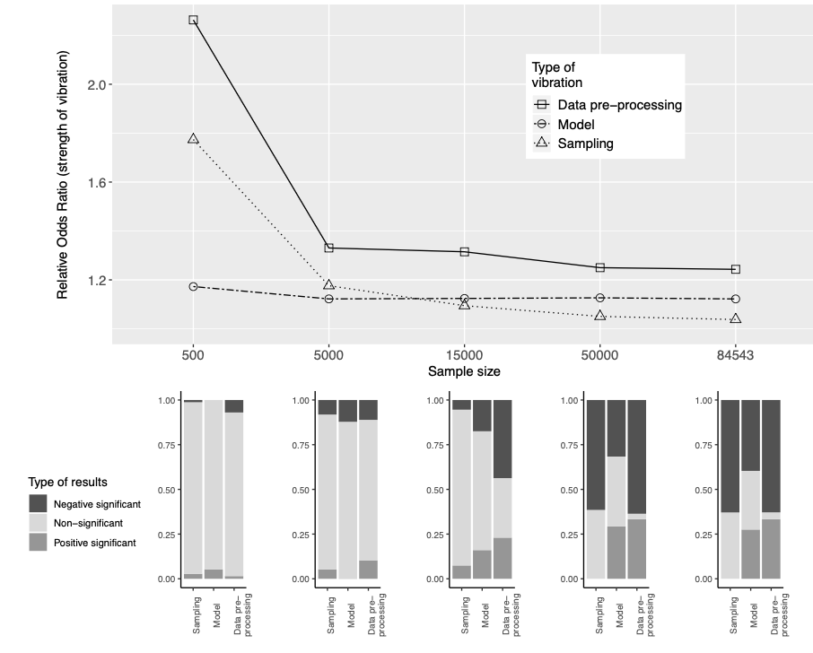

Klau et al. (2020): Data pre-processing, model, and sampling vibration for diﬀerent sample sizes (top panel), with bar plots visualizing the type of results in terms of significance of eﬀects for association between neuroticism and relationship status

## Exposing uncertainty

Variation in effects estimates given variation in (Landy et al., 2020):

- Stimulus materials construction choices

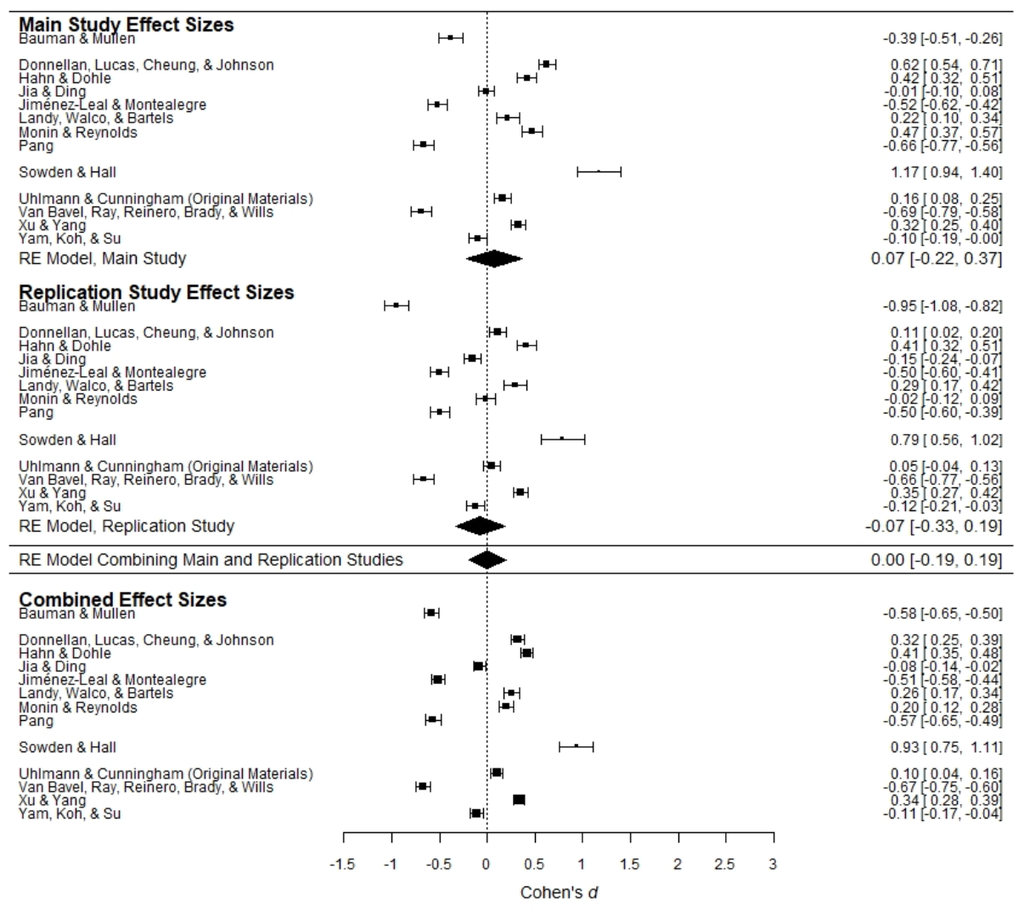

Landy et al. (2020): Forest plot of observed effect sizes for research question: ‘When directly asked, do people explicitly self-report an awareness of harboring negative automatic associations with members of negatively stereotyped social groups?’

## Exposing uncertainty

Variation in effects estimates given variation in (Steegen et al., 2016):

- Data construction choices

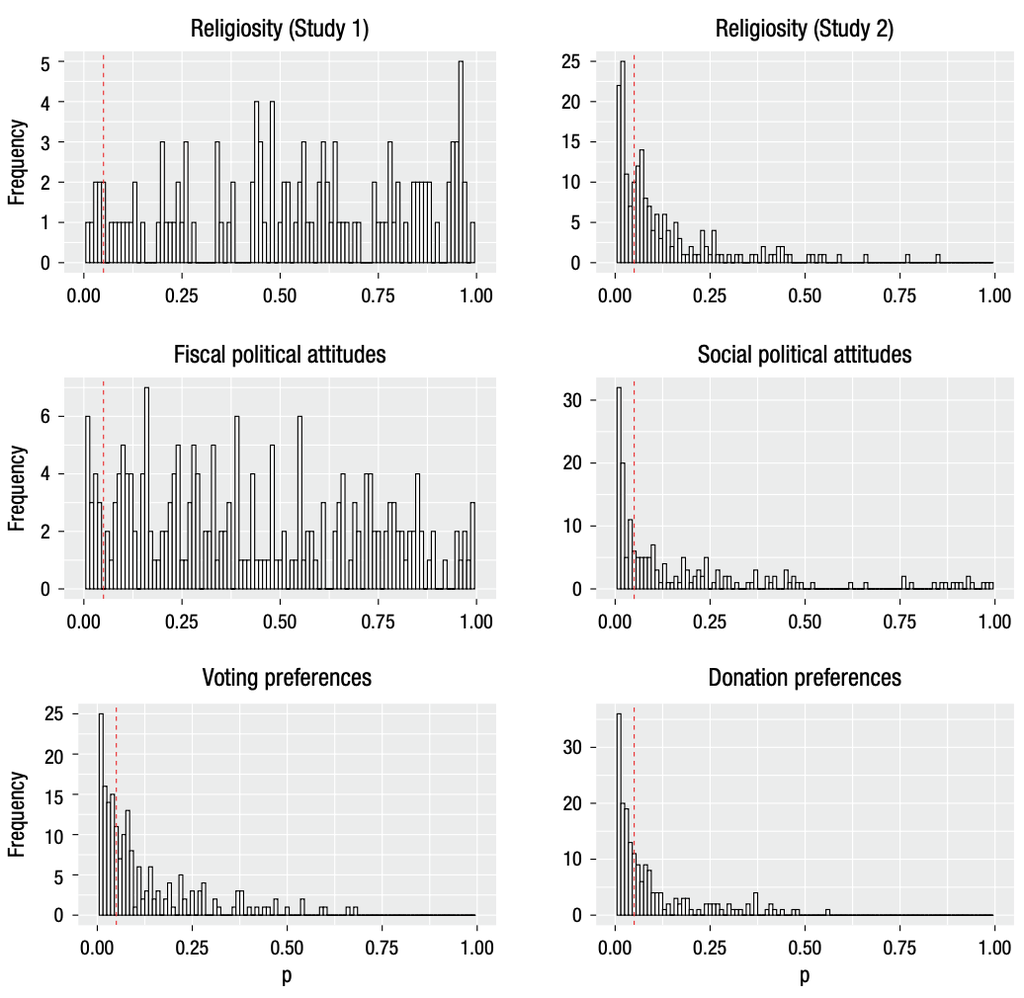

Steegen et al. (2016): Histogram of p values of the Fertility × Relationship status interaction on religiosity for the multiverse of 120 data sets in Study 1 and 210 data sets in Study 2 (Panels A and B), on fiscal and social political attitudes for the multiverse of 210 data sets in Study 2 (Panels C and D), and on voting and donation preferences for the multiverse of 210 data sets in Study 2 (Panels E and F)

## Multiverse analyses of uncertainty

*Multiverse* analyses suggest estimates of psychological effects (phenomena) vary (Silberzahn & Uhlmann, 2015)

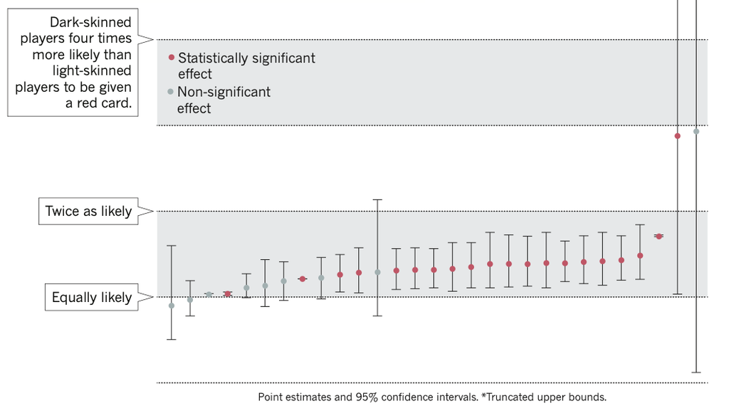

Silberzahn & Uhlmann (2015): Variation in effects estimates by different analysis teams

## Multiverse analyses of uncertainty

Auspurg & Brüderl (2021) argue this happens when researchers don’t know how to interpret the research question

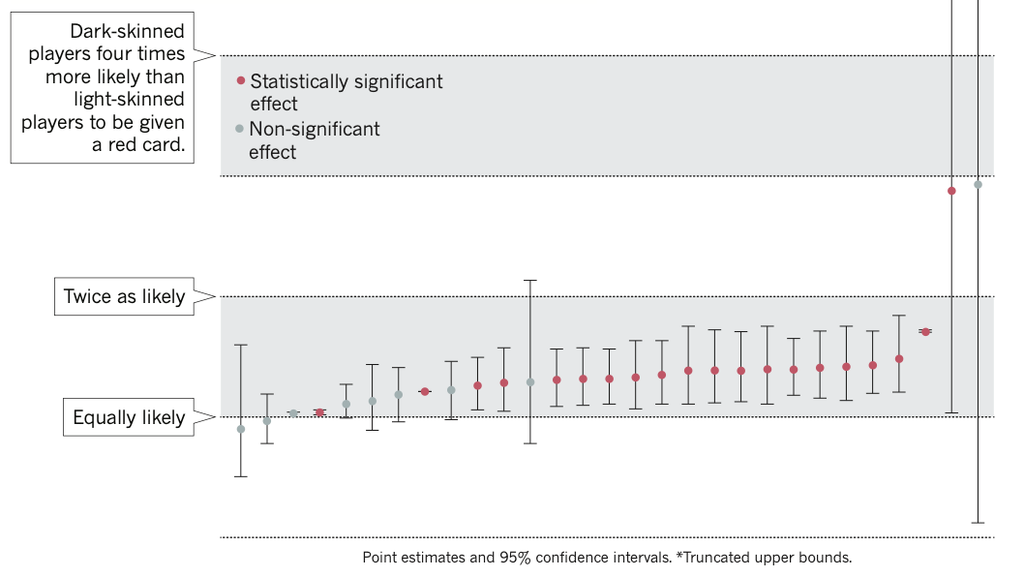

Silberzahn & Uhlmann (2015): Variation in effects estimates by different analysis teams

## Levels of uncertainty

McElreath (2020) further distinguishes levels of uncertainty over model predictions (supposing data collection, sampling, pre-processing, and model choices):

- The ways that population outcomes are predicted to vary *on average* given a model
- The ways that specific responses can be produced given model average predictions

## Levels of uncertainty

Hofman et al. (2020) explain

- Inferential uncertainty: the degree to which a summary statistic is known to the scientist
  - We can reduce inferential uncertainty by collecting more data e.g. gathering a larger sample to get to a more precise estimate of average height
- Outcome uncertainty: how much individual outcomes vary about the summart statistic regardless of how well it has been estimated
  - Even with a large sample and precise estimate of the average, individual heights will still vary

## Visualizations of uncertainty

- Scientists often choose to display inferential uncertainty (precision of statistical estimates) using confidence intervals
  - But depicting inferential uncertainty alone causes participants to overstate beliefs in effects and to understate variability in individual outcomes (Hofman et al., 2020)
  - Readers think that results are more definitive than they really are (Zhang et al., 2023)

## Visualizations of uncertainty

- Hofman et al. (2020): visualizations oriented to inferential uncertainty (95% CIs) led to greatest deviation from correct answers
  - Misperceptions largest for visualizations depicting smaller effect sizes
  - Many scientific results are likely exaggerated in the minds of some readers
  - Biases could mean excessive faith in effect of interventions

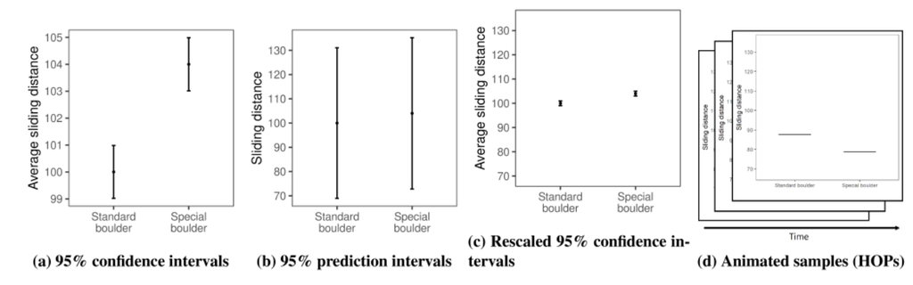

Hofman et al. (2020): Compare visualizations (a) focus on inferential uncertainty (uncertainty in predicting the mean); (b) presents information about outcome uncertainty (variation in individual outcomes); (c) hybrid including information about both inferential and outcome uncertainty; and (d) presenting animated samples of individual outcomes

## Visualizations of uncertainty

- Zhang et al. (2023): emphasis on inference over prediction
- Responses to plots reveal biases even among expert readers:
  - The *Illusion of predictability*

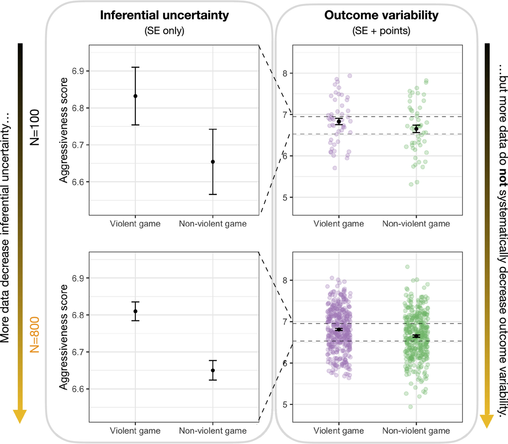

Zhang et al. (2023): Inferential uncertainty vs. outcome variability. (Left) Estimated means and an error bar representing one SE above and one SE below the mean, for two conditions in an experiment. (Right) Individual outcomes shown in addition to the same SEs on the Left

## Effects of communicating uncertainty on public trust in facts and numbers

- van der Bles et al. (2020): Does openly communicating uncertainty around facts and numbers necessarily undermine audiences’ trust in the facts, or the communicators?
  - People do perceive greater uncertainty when it is communicated
    - through numerical ranges with a point estimate
  - Only small decrease in trust in numbers or in perceived trustworthiness of the information source

## Generalizability: we can *never* test all the people on all the things

## Researchers often make claims about the generalizability of their findings

Yarkoni (2022): we need to be careful in analyses and in presentations of analyses about the alignment between verbal hypotheses and statistical tests

- Is our *operationalization* of our constructs valid: do the things we measure capture the things we say they measure, and do those things actually exist (see also Borsboom et al., 2004)?
- Is our statement of theory, including who or what the theory applies to, adequately captured by our statistical model?

## Researchers often make claims about the generalizability of their findings

- Yarkoni (2022): if we are doing research involving the presentation of samples of stimuli to samples of participants, given some task(-s) (see also Brunswik, 1955; Clark, 1973)
  - We need to account for sources of sampling variance in study designs and analyses
    - We may do this by incorporating random effects: adding to our account of uncertainty
  - So we can then make reasonable claims about generalizability to the populations we are thinking about

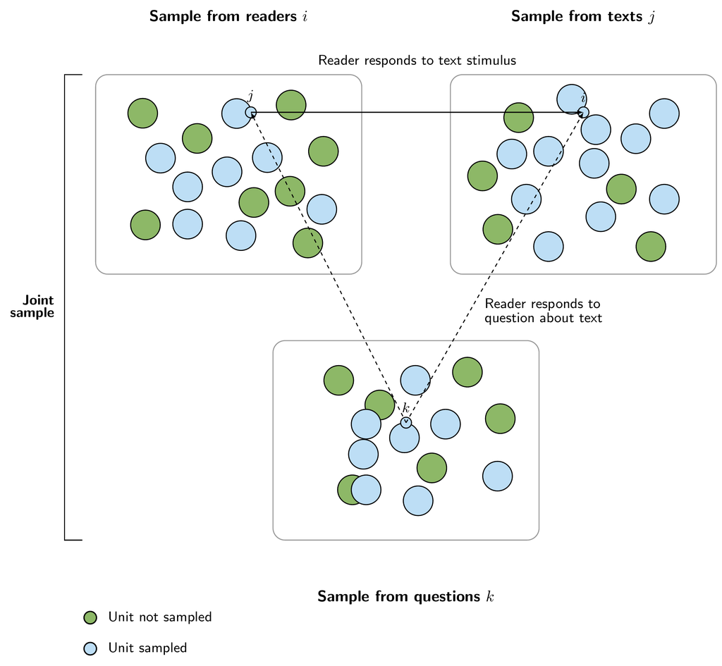

Figure 1: Normally, when we do psychological studies, we ask a sample of people to respond to a sample of stimuli

## Researchers often make claims about the generalizability of their findings

- Questions about generalizability relate not just to participant or stimulus sampling but also to things like task demands (Brunswik, 1955; Yarkoni, 2022)

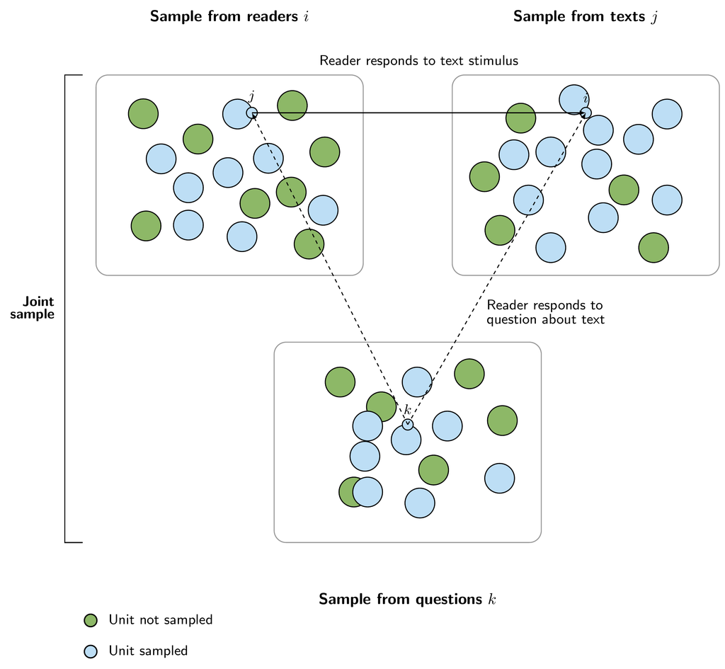

Figure 2: Normally, when we do psychological studies, we ask a sample of people to respond to a sample of stimuli

## Constraints on generalizability

- Simons et al. (2017): recommend that we include Constraints on Generality (COG) statements in our reports
  - few papers identify their target populations
  - fewer papers justify how or why the tested samples are representative of broader populations

## Constraints on generalizability

- Simons et al. (2017): there may be incentives to make the strongest possible claim of generality
- But failure to specify target populations contributes to problems in scientific communication, leaving uncertainty about
  - how or to whom reported findings generalize
  - what would be required for direct replications or for conceptual replications

## Constraints on generalizability

Simons et al. (2017) recommend including a COG statement in discussions to explicate:

- Known empirical or theoretical boundary conditions
  - How is your sample of participants representative of a broader target population
  - The class of materials/stimuli to which your finding should generalize
  - What aspects of procedure are critical to reproducing the finding
  - Historical or temporal transparency

## Transparency around claims on causality

- There is a taboo against addressing causal research questions and avoid drawing causal inference on the basis of nonexperimental evidence (Grosz et al., 2020)
  - But this results in a disconnect between original findings and how they are interpreted in subsequent work
  - Better to to talk openly about causal assumptions

**How science works and theory**

Revisit our discussions of theory to reflect on causal claims

## Incentives

- Proulx & Morey (2021) criticize recent emphasis in normative psychological science practices on:
  - “interesting research” that is salient to the lay intuitions of the general public
  - findings that are “surprising”, novel and counterintuitive relative to common intuitions and established theory
  - research that is “groundbreaking”

**Tip**

We discuss the response to these problematic attitudes in our discussion of theory

## No, it’s not the incentives, it’s you

Yarkoni (2018): we have to be careful

- An account of the prevalence of (perverse) incentives
- Does not absolve us of our personal responsibilities

## Obligations and responsibilities for the scientist in society

- It is our responsibility to put things in the public domain and to make claims on attention for useful or helpful observations
  - Especially if our work was publicly funded
- But we must engage with our obligations also to be clear about limits on credibility: uncertainty, generalizability, and the identification of causal mechanisms

## Activate

Our learning questions are this:

**Activate**

1. What do we do?
2. What can we do?
3. What should we do?

## The complex link between science and story telling

**Story telling and science**

We are going to learn about the complex link between science and story telling

## Science is claimed to be getting less readable over time

Concerns over readability are one reason why science communication advice embraces “plain language” (DuBay, 2004; Schriver, 2017)

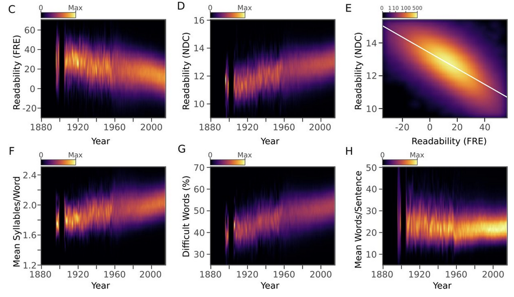

Plavén-Sigray et al. (2017): In a corpus consisting of 709,577 abstracts published between 1881 and 2015 from 123 scientific journals, the readability of science is steadily decreasing. This trend is indicative of a growing use of general scientific jargon.

## Science communiction experts recommend plain language

- Use short, common, words
- Use short simple sentences, paragraphs
- Explain jargon but avoid jargon if you can
- Avoid the passive voice

**Guidance can be questioned**

Communication guidance is not tied to direct evidence that following recommendations “works”

## The response to scientific communication relies on cognitive short-cuts

Scientific jargon can be satisfying but misleading (Cruz & Lombrozo, 2025)

- Jargon increases satisfaction because laypeople assume the jargon fills gaps in explanations that are otherwise incomplete

## Story telling is critical to the practice of science

In Peterson (2016)’s ethnographic study of baby labs, we see:

> The structure of these meetings was similar across labs. A professor or graduate student would e-mail a short document to the lab a few days before and then hand out those same pages at the beginning of the meeting. Usually, they would contain a couple of box plots or bar charts. The experimenter would then point out where statistical significance was reached and then ask the lab for help figuring out what could be argued from the results. The lab would attempt to collectively craft a story out of the significant findings.

[Emphasis added.]

## Stories are for telling, stories are for *thinking*

- Stories are central to engagement with the development and evaluation of theories (Gelman & Basbøll, 2014)
- But for a story to be useful in this way, it should be:
  - *anomalous* representing aspects of life that are not well explained by existing models
  - *immutable* carrying details that are well-enough established that they have the potential to indicate problems with a new model

## Consider carefully how we may link research to policy

There is plenty of advice on how to create impact or influence policy (Oliver & Cairney, 2019), including (most relevant to our concerns):

- Conduct high-quality, robust research
- Provide it in a way that is:
  - timely
  - policy relevant
  - easy to understand (but not at the expense of accuracy)
- Engage in more effective dissemination, using a range of outputs (social media, blogs, policy briefs),
- Use storytelling techniques to persuade policymakers of a course of action or to better communicate scientific ideas

## Consider carefully how we may link research to policy

- This advice is not based on empirical evidence, or on good understandings of key literatures on policymaking or evidence use (Oliver & Cairney, 2019)
- A critical interrogation reveals important dilemmas:
  - Should you ‘co-produce’ research and policy and give policy recommendations?
  - What are the causes of unequal rewards and punishments for engagement?
  - Is engagement an event or (more likely) a career choice?

## Consider carefully how we may link research to policy

What then are we to make of recommendations to:

- Engage in more effective dissemination
  - Avoid jargon but don’t over-simplify
  - Make simple and definitive statements
  - Produce good stories based on emotional appeals or humour to expand and engage your audience
  - Produce narrative through scene-setting, casting characters, establishing a plot, and equating the moral with a ‘solution to the policy problem’

## How we may link research to policy

What uncertainties are inherent in the current limitations of evidence on what works?

- There is no consensus over what counts as good evidence for policy or how best to communicate good evidence
- Policy-makers may seek cognitive shortcuts to avoid decision-making ‘paralysis’ and allow them to process information efficiently enough to make choices
  - This means we need to understand how policy-makers use such shortcuts to interpret their world, pay attention to issues, define policy problems, and respond to proposed solutions

## The ethics of persuasive language

Be aware of the ethics of using persuasive language or structure (Bajraktari & Munafò, 2026)

- Scientific communication is often assumed to prioritize objectivity, yet persuasive strategies may subtly distort research interpretation

## The ethics of persuasive language

Bajraktari & Munafò (2026):

- Research reports are not just neutral reports of facts
- They are narratives: rhetorical constructions shaped by disciplinary norms, cultural contexts and social expectations

## The ethics of persuasive language

Bajraktari & Munafò (2026):

- The pressure to publish is a well-documented feature of research culture
- Most researchers consider persuasion to be “Sometimes” or “Most of the time” necessary for publication
  - Because it is required by journal editors or by peer reviewers
- Journal expectations and peer review processes can encourage authors to emphasize the novelty or significance of their findings

## Persuasive devices as questionable research practices

Bajraktari & Munafò (2026):

- Researchers recognize as attempts to persuade the use of devices like: “Misleading interpretation”, “selective reporting”, “inappropriate extrapolation”, “overgeneralization”, “hype” and “spin”
- Many of these devices overlap with questionable research practices (Nagy et al., 2025)
- But the QRP framing may be unhelpful

## Critical reflections on the use of persuasive devices

Corneille et al. (2023) reflected on our own writing styles, and on the writing styles they encountered

- All writing that is intended for publication should be clear and engaging
- and the authors of scientific articles can use a wide range of persuasive communication devices to achieve these goals
- It is also possible for these devices to be mis-used in ways that can mislead readers

## Critical reflections on the use of persuasive devices

Corneille et al. (2023):

- Researchers are at risk of misleading the reader about the novelty or strength of their research when they make inaccurate statements about the current state of scientific knowledge
  - failing to cite articles that are relevant
  - citing articles that are not relevant
  - misleading the reader about other work through selective quotation, misquotation, or quotation out of context

## Critical reflections on the use of persuasive devices

Corneille et al. (2023):

- Authors can try to inflate the perceived importance of their own research
  - Use of attention-grabbing titles
  - Overgeneralizing their conclusions without sufficient evidence

## Critical reflections on the use of persuasive devices

Corneille et al. (2023):

- The perceived coherence of the narrative can also be increased by
  - not reporting findings that would weaken the article
  - by claiming that the results were consistent with a hypothesis when, in fact, the hypothesis was generated after the data had been collected
- Writing that is cryptic, obscure or undecipherable can grant a false sense of expertise and prevent fair assessment

## Critical reflections on the use of persuasive devices

Corneille et al. (2023):

- Superficial engagement with open research practices can also be used to mislead readers and reviewers about the strength of research
- An author may seek to overwhelm the reader with large volumes of poorly structured/explained supplementary material in order to prevent scrutiny of a paper’s conclusions (see also Towse et al., 2021)

## Summary: Critical reflections

- We work as scientists in society
- This imposes incentives or pressures as well as obligations or responsibilities
- We may have to tell stories about our work
- We can choose what kinds of stories we tell, and how we tell them
- It would be useful to recognize our actions, to see ourselves in our actions, and to decide on what it is we want to see

## End notes

Our learning questions are this:

**Activate**

1. What are the pressures?
2. What are our responsibilities?
3. What can we or should we do?

## References

Auspurg, K., & Brüderl, J. (2021). Has the Credibility of the Social Sciences Been Credibly Destroyed? Reanalyzing the “Many Analysts, One Data Set” Project. *Socius*, *7*, 23780231211024421. https://doi.org/10.1177/23780231211024421

Bajraktari, R., & Munafò, M. (2026). Persuasion in Scientific Journal Articles: Exploring Persuasiveness and Informativeness among Authors and Readers. *Journal of Trial and Error*. https://doi.org/10.36850/b364-4157

Baldwin, M. (2018). Scientific Autonomy, Public Accountability, and the Rise of “Peer Review” in the Cold War United States. *Isis*, *109*(3), 538–558. https://doi.org/10.1086/700070

Bartscherer, S. F. (2026). *Cultures of Trial and Error: The Narrative Side of (Open) Science*. https://doi.org/10.36850/448e9a73-75b2

Borsboom, D., Mellenbergh, G. J., & van Heerden, J. (2004). The concept of validity. *Psychological Review*, *111*(4), 1061–1071. https://doi.org/10.1037/0033-295X.111.4.1061

Bourdieu, P. (2004). *Science of science and reflexivity*. Polity.

Brunswik, E. (1955). Representative design and probabilistic theory in a functional psychology. *Psychological Review*, *62*(3), 193–217. https://doi.org/10.1037/h0047470

Clark, H. H. (1973). The language-as-fixed-effect fallacy: A critique of language statistics in psychological science. *Journal of Verbal Learning and Verbal Behaviour*, *12*, 335–359.

Corneille, O., Havemann, J., Henderson, E. L., IJzerman, H., Hussey, I., Orban de Xivry, J.-J., Jussim, L., Holmes, N. P., Pilacinski, A., Beffara, B., Carroll, H., Outa, N. O., Lush, P., & Lotter, L. D. (2023). Beware “persuasive communication devices” when writing and reading scientific articles. *eLife*, *12*, e88654. https://doi.org/10.7554/eLife.88654

Cruz, F., & Lombrozo, T. (2025). How laypeople evaluate scientific explanations containing jargon. *Nature Human Behaviour*, *9*(10), 2038–2053. https://doi.org/10.1038/s41562-025-02227-0

Danziger, K. (1990). *Constructing the Subject: Historical Origins of Psychological Research*. Cambridge University Press. https://doi.org/10.1017/CBO9780511524059

Delawalla, C., Ambros, V., Bergstrom, C., Greider, C., Mann, M., & Nosek, B. (2025, May 29). Trump’s new ’gold standard’ rule will destroy American science as we know it. *The Guardian: Opinion*. https://www.theguardian.com/commentisfree/2025/may/29/trump-american-science

DuBay, W. H. (2004). *The principles of readability*. Impact Information.

Gelman, A., & Basbøll, T. (2014). When Do Stories Work? Evidence and Illustration in the Social Sciences. *Sociological Methods & Research*, *43*(4), 547–570. https://doi.org/10.1177/0049124114526377

Gigerenzer, G. (1993). The superego, the ego, and the id in statistical reasoning. In *A handbook for data analysis in the behavioral sciences: Methodological issues* (pp. 311–339). Lawrence Erlbaum Associates, Inc.

Grosz, M. P., Rohrer, J. M., & Thoemmes, F. (2020). The Taboo Against Explicit Causal Inference in Nonexperimental Psychology. *Perspectives on Psychological Science*, *15*(5), 1243–1255. https://doi.org/10.1177/1745691620921521

Hofman, J. M., Goldstein, D. G., & Hullman, J. (2020). How Visualizing Inferential Uncertainty Can Mislead Readers About Treatment Effects in Scientific Results. *Proceedings of the 2020 CHI Conference on Human Factors in Computing Systems, CHI ’20*, 1–12. https://doi.org/10.1145/3313831.3376454

Klau, S., Hoffmann, S., Patel, C. J., Ioannidis, J. P., & Boulesteix, A.-L. (2021). Examining the robustness of observational associations to model, measurement and sampling uncertainty with the vibration of effects framework. *International Journal of Epidemiology*, *50*(1), 266–278. https://doi.org/10.1093/ije/dyaa164

Klau, S., Schönbrodt, F., Patel, C., Ioannidis, J., Boulesteix, A.-L., & Hoffmann, S. (2020). *Comparing the vibration of effects due to model, data pre-processing and sampling uncertainty on a large data set in personality psychology*. https://epub.ub.uni-muenchen.de/70485/1/SAPA_Technical_Report.pdf

Kuhn, T. S. (1970). *The structure of scientific revolutions* ([2d ed., enl). University of Chicago Press.

Landy, J. F., Jia, M. (Liam)., Ding, I. L., Viganola, D., Tierney, W., Dreber, A., Johannesson, M., Pfeiffer, T., Ebersole, C. R., Gronau, Q. F., Ly, A., van den Bergh, D., Marsman, M., Derks, K., Wagenmakers, E.-J., Proctor, A., Bartels, D. M., Bauman, C. W., Brady, W. J., … Uhlmann, E. L. (2020). Crowdsourcing hypothesis tests: Making transparent how design choices shape research results. *Psychological Bulletin*, *146*(5), 451–479. https://doi.org/10.1037/bul0000220

McElreath, R. (2020). *Statistical rethinking: A Bayesian Course with Examples in R and STAN* (2nd ed.). Chapman and Hall/CRC. https://doi.org/10.1201/9780429029608

Munafò, M. R., Nosek, B. A., Bishop, D. V. M., Button, K. S., Chambers, C. D., Percie Du Sert, N., Simonsohn, U., Wagenmakers, E. J., Ware, J. J., & Ioannidis, J. P. A. (2017). A manifesto for reproducible science. *Nature Human Behaviour*, *1*(1), 1–9. https://doi.org/10.1038/s41562-016-0021

Nagy, T., Hergert, J., Elsherif, M. M., Wallrich, L., Schmidt, K., Waltzer, T., Payne, J. W., Gjoneska, B., Seetahul, Y., Wang, Y. A., Scharfenberg, D., Tyson, G., Yang, Y.-F., Skvortsova, A., Alarie, S., Graves, K., Sotola, L. K., Moreau, D., & Rubínová, E. (2025). Bestiary of Questionable Research Practices in Psychology. *Advances in Methods and Practices in Psychological Science*, *8*(3), 25152459251348431. https://doi.org/10.1177/25152459251348431

Nosek, B. A., Hardwicke, T. E., Moshontz, H., Allard, A., Corker, K. S., Dreber, A., Fidler, F., Hilgard, J., Kline Struhl, M., Nuijten, M. B., Rohrer, J. M., Romero, F., Scheel, A. M., Scherer, L. D., Schönbrodt, F. D., & Vazire, S. (2022). Replicability, Robustness, and Reproducibility in Psychological Science. *Annual Review of Psychology*, *73*, 719–748. https://doi.org/10.1146/annurev-psych-020821-114157

Oliver, K., & Cairney, P. (2019). The dos and don’ts of influencing policy: A systematic review of advice to academics. *Palgrave Communications*, *5*(1), 21. https://doi.org/10.1057/s41599-019-0232-y

Peterson, D. (2016). The Baby Factory: Difficult Research Objects, Disciplinary Standards, and the Production of Statistical Significance. *Socius*, *2*, 2378023115625071. https://doi.org/10.1177/2378023115625071

Plavén-Sigray, P., Matheson, G. J., Schiffler, B. C., & Thompson, W. H. (2017). The readability of scientific texts is decreasing over time. *eLife*, *6*, e27725. https://doi.org/10.7554/eLife.27725

Proulx, T., & Morey, R. D. (2021). Beyond Statistical Ritual: Theory in Psychological Science. *Perspectives on Psychological Science*, *16*(4), 671–681. https://doi.org/10.1177/17456916211017098

Schriver, K. A. (2017). Plain Language in the US Gains Momentum: 1940–2015. *IEEE Transactions on Professional Communication*, *60*(4), 343–383. https://doi.org/10.1109/TPC.2017.2765118

Silberzahn, R., & Uhlmann, E. L. (2015). Crowdsourced research: Many hands make tight work. *Nature*, *526*(7572), 189–191. https://doi.org/10.1038/526189a

Simons, D. J., Shoda, Y., & Lindsay, D. S. (2017). Constraints on Generality (COG): A Proposed Addition to All Empirical Papers. *Perspectives on Psychological Science*, *12*(6), 1123–1128. https://doi.org/10.1177/1745691617708630

Spier, R. (2002). The history of the peer-review process. *Trends in Biotechnology*, *20*(8), 357–358. https://doi.org/10.1016/S0167-7799(02)01985-6

Steegen, S., Tuerlinckx, F., Gelman, A., & Vanpaemel, W. (2016). Increasing transparency through a multiverse analysis. *Perspectives on Psychological Science*, *11*(5), 702–712.

Towse, J. N., Ellis, D. A., & Towse, A. S. (2021). Opening Pandora’s Box: Peeking inside Psychology’s data sharing practices, and seven recommendations for change. *Behavior Research Methods*, *53*(4), 1455–1468. https://doi.org/10.3758/s13428-020-01486-1

Trump, D. J. (2025). *Restoring Gold Standard Science* [Executive Order]. US Government. https://www.whitehouse.gov/presidential-actions/2025/05/restoring-gold-standard-science/

van der Bles, A. M., van der Linden, S., Freeman, A. L. J., & Spiegelhalter, D. J. (2020). The effects of communicating uncertainty on public trust in facts and numbers. *Proceedings of the National Academy of Sciences*, *117*(14), 7672–7683. https://doi.org/10.1073/pnas.1913678117

Vazire, S. (2018). Implications of the credibility revolution for productivity, creativity, and progress. *Perspectives on Psychological Science*, *13*(4), 411–417. https://doi.org/10.1177/1745691617751884

Yarkoni, T. (2018, October 2). *No, it’s not The Incentives—it’s you*. [citation needed]. https://talyarkoni.org/blog/2018/10/02/no-its-not-the-incentives-its-you/

Yarkoni, T. (2022). The generalizability crisis. *Behavioral and Brain Sciences*, *45*, e1. https://doi.org/10.1017/S0140525X20001685

Zhang, S., Heck, P. R., Meyer, M. N., Chabris, C. F., Goldstein, D. G., & Hofman, J. M. (2023). An illusion of predictability in scientific results: Even experts confuse inferential uncertainty and outcome variability. *Proceedings of the National Academy of Sciences*, *120*(33), e2302491120. https://doi.org/10.1073/pnas.2302491120